# Clasificación de un Compuesto de Medianas

En el presente notebook se hace la clasificación de un compuesto temporal de medianas extraido del repositorio de imgágenes del **Cubo de Datos de Imágenes de Satélite de Colombia** en el IDEAM. Un compuesto es un una imagen libre de nubes contruida por medio de una serie de tomas en el tiempo.

## Referencias

1. http://cdcol.ideam.gov.co/profile/home/

```python
%matplotlib inline

import xarray as xr
import numpy as np
import matplotlib.pyplot as plt
```

## Carga de un Archivo tif

La función **open_rasterio** permite cargar los datos deun archivo Geotiff en un arreglo multidimensional. La forma del arreglo depende de cómo haya sido generado el archivo por parte del IDEAM.

```python
data = xr.open_rasterio('../data/prueba/pequena.tif')
print('Shape:', data.shape)
data.values
```

```
Shape: (6, 3687, 3705)
```

```
array([[[ 275.5,  260. ,  218. , ..., 1076. ,  999. ,  950.5],
        [ 325. ,  251. ,  264.5, ..., 1017. , 1002.5,  859. ],
        [ 278. ,  322. ,  262.5, ...,  961. ,  880.5,  801.5],
        ...,
        [ 562. ,  599. ,  553. , ..., 1085.5, 1022. , 1139. ],
        [ 541. ,  564. ,  568. , ...,  879.5,  782. ,  803. ],
        [ 495. ,  509. ,  566. , ...,  973. ,  869. ,  793. ]],

       [[ 181. ,  175.5,  155. , ..., 2120.5, 2009. , 1928. ],
        [ 205. ,  168.5,  178.5, ..., 2081. , 2016.5, 1807. ],
        [ 181. ,  185. ,  176. , ..., 2096. , 1915. , 1777. ],
        ...,
        [ 815. ,  884. ,  815. , ..., 1032. , 1271. , 2090.5],
        [ 807. ,  855. ,  866. , ..., 1507. , 1274. , 1364. ],
        [ 699. ,  782. ,  852. , ..., 1195. , 1026. , 1370. ]],

       [[ 213.5,  196.5,  153. , ..., 2378. , 2290. , 2236. ],
        [ 251. ,  196.5,  194.5, ..., 2366. , 2334.5, 2140. ],
        [ 204. ,  245. ,  195. , ..., 2306. , 2188.5, 2111.5],
        ...,
        [3948. , 3969. , 4103. , ..., 4025.5, 3753. , 3041. ],
        [4188. , 3996. , 4070. , ..., 3046.5, 2967.5, 2902.5],
        [4174. , 3999. , 3925. , ..., 2581. , 2745. , 2749. ]],

       [[ 377. ,  372. ,  322. , ...,  639.5,  608.5,  593.5],
        [ 443. ,  367.5,  361. , ...,  630.5,  630. ,  559.5],
        [ 406. ,  405. ,  354.5, ...,  600.5,  563.5,  520. ],
        ...,
        [ 227. ,  258. ,  230. , ...,  431. ,  434. ,  731.5],
        [ 214. ,  230. ,  254. , ...,  434.5,  396.5,  406. ],
        [ 202. ,  211. ,  238. , ...,  478. ,  384. ,  412. ]],

       [[ 215. ,  197. ,  157. , ..., 1364.5, 1287. , 1197.5],
        [ 254. ,  189. ,  196.5, ..., 1316. , 1293. , 1096.5],
        [ 209. ,  244. ,  202. , ..., 1261. , 1144. , 1026. ],
        ...,
        [ 348. ,  377. ,  331. , ...,  879.5,  898.5, 1263. ],
        [ 332. ,  375. ,  366. , ...,  986.5,  880. ,  864. ],
        [ 291. ,  323. ,  390. , ..., 1122. ,  838. ,  757. ]],

       [[ 213.5,  209.5,  174. , ..., 3082. , 2968.5, 2879. ],
        [ 250. ,  202.5,  212. , ..., 3088. , 2990. , 2769. ],
        [ 224. ,  233. ,  201.5, ..., 3104.5, 2929.5, 2784. ],
        ...,
        [1914. , 1992. , 1931. , ..., 2083. , 2328.5, 3018. ],
        [1986. , 2067. , 1990. , ..., 2491. , 2154. , 2241.5],
        [1816. , 1924. , 2060. , ..., 2012. , 1811. , 2165. ]]],
      dtype=float32)
```

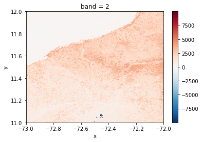

```python
# Muestra de una banda de la imágen multi espectral
data[1].plot()
```

## Transformación del Arreglo para la Clasificación

La transformación consiste en transponer el arrleglo multidimensional de tal forma que los valores de las bandas queden en un arreglo y no dispersos en diferentes arreglos. El siguie ejemplo es una muestra de la salida anterior. El primer arreglo bidimencional (commienza con **275.5**) corresponde a los datos en latitud y longitud de la primera banda de la imagén. El segundo arreglo commienza con **181.**) corresponde a la segúnda banda de la imágen.

```
[[ **275.5**,  260. ,  218. , ..., 1076. ,  999. ,  950.5],
[ 325. ,  251. ,  264.5, ..., 1017. , 1002.5,  859. ],
[ 278. ,  322. ,  262.5, ...,  961. ,  880.5,  801.5],
...,
[ 562. ,  599. ,  553. , ..., 1085.5, 1022. , 1139. ],
[ 541. ,  564. ,  568. , ...,  879.5,  782. ,  803. ],
[ 495. ,  509. ,  566. , ...,  973. ,  869. ,  793. ]],

[[ **181.** ,  175.5,  155. , ..., 2120.5, 2009. , 1928. ],
[ 205. ,  168.5,  178.5, ..., 2081. , 2016.5, 1807. ],
[ 181. ,  185. ,  176. , ..., 2096. , 1915. , 1777. ],
...,
[ 815. ,  884. ,  815. , ..., 1032. , 1271. , 2090.5],
[ 807. ,  855. ,  866. , ..., 1507. , 1274. , 1364. ],
[ 699. ,  782. ,  852. , ..., 1195. , 1026. , 1370. ]]
```

El objetivo de este paso es que los valores de las bandas **275.5** **181.** queden en la misma lista para facilitar el procesamiento de la imágen. La salida entonces es algo similar a

```
[[[ **275.5**,  **181.** ,  213.5,  377. ,  215. ,  213.5],
    [ 325. ,  205. ,  251. ,  443. ,  254. ,  250. ],
    [ 278. ,  181. ,  204. ,  406. ,  209. ,  224. ],
    ...,
```

```python
inv = np.transpose(data.values)
print('Shape:', inv.shape)
inv
```

```
Shape: (3705, 3687, 6)
```

```
array([[[ 275.5,  181. ,  213.5,  377. ,  215. ,  213.5],
        [ 325. ,  205. ,  251. ,  443. ,  254. ,  250. ],
        [ 278. ,  181. ,  204. ,  406. ,  209. ,  224. ],
        ...,
        [ 562. ,  815. , 3948. ,  227. ,  348. , 1914. ],
        [ 541. ,  807. , 4188. ,  214. ,  332. , 1986. ],
        [ 495. ,  699. , 4174. ,  202. ,  291. , 1816. ]],

       [[ 260. ,  175.5,  196.5,  372. ,  197. ,  209.5],
        [ 251. ,  168.5,  196.5,  367.5,  189. ,  202.5],
        [ 322. ,  185. ,  245. ,  405. ,  244. ,  233. ],
        ...,
        [ 599. ,  884. , 3969. ,  258. ,  377. , 1992. ],
        [ 564. ,  855. , 3996. ,  230. ,  375. , 2067. ],
        [ 509. ,  782. , 3999. ,  211. ,  323. , 1924. ]],

       [[ 218. ,  155. ,  153. ,  322. ,  157. ,  174. ],
        [ 264.5,  178.5,  194.5,  361. ,  196.5,  212. ],
        [ 262.5,  176. ,  195. ,  354.5,  202. ,  201.5],
        ...,
        [ 553. ,  815. , 4103. ,  230. ,  331. , 1931. ],
        [ 568. ,  866. , 4070. ,  254. ,  366. , 1990. ],
        [ 566. ,  852. , 3925. ,  238. ,  390. , 2060. ]],

       ...,

       [[1076. , 2120.5, 2378. ,  639.5, 1364.5, 3082. ],
        [1017. , 2081. , 2366. ,  630.5, 1316. , 3088. ],
        [ 961. , 2096. , 2306. ,  600.5, 1261. , 3104.5],
        ...,
        [1085.5, 1032. , 4025.5,  431. ,  879.5, 2083. ],
        [ 879.5, 1507. , 3046.5,  434.5,  986.5, 2491. ],
        [ 973. , 1195. , 2581. ,  478. , 1122. , 2012. ]],

       [[ 999. , 2009. , 2290. ,  608.5, 1287. , 2968.5],
        [1002.5, 2016.5, 2334.5,  630. , 1293. , 2990. ],
        [ 880.5, 1915. , 2188.5,  563.5, 1144. , 2929.5],
        ...,
        [1022. , 1271. , 3753. ,  434. ,  898.5, 2328.5],
        [ 782. , 1274. , 2967.5,  396.5,  880. , 2154. ],
        [ 869. , 1026. , 2745. ,  384. ,  838. , 1811. ]],

       [[ 950.5, 1928. , 2236. ,  593.5, 1197.5, 2879. ],
        [ 859. , 1807. , 2140. ,  559.5, 1096.5, 2769. ],
        [ 801.5, 1777. , 2111.5,  520. , 1026. , 2784. ],
        ...,
        [1139. , 2090.5, 3041. ,  731.5, 1263. , 3018. ],
        [ 803. , 1364. , 2902.5,  406. ,  864. , 2241.5],
        [ 793. , 1370. , 2749. ,  412. ,  757. , 2165. ]]], dtype=float32)
```

## Carga del Modelo de Machine Learning y Clasificación de la Imágen Multiespectral

```python
from keras.models import load_model
model = load_model("my_model.h5")
```

```python
def compute(array):
    probabilities = []
    for i in range(0,array.shape[0]):
        probabilities.append(model.predict(array[i]))

    result = np.array(probabilities)
    # Axis = 2 es la dimesnion que contiene las probabilidad des
    # de las predicciones realizadas sobre las bandas espectrales
    result = np.argmax(result,axis=2)
    result = np.transpose(result)
    return result

%time clasified = compute(inv)
```

```
CPU times: user 32.4 s, sys: 43.9 ms, total: 32.4 s
Wall time: 32.4 s
```

```python
clasified
```

```
array([[0, 0, 0, ..., 3, 3, 3],
       [0, 0, 0, ..., 3, 3, 3],
       [0, 0, 0, ..., 3, 3, 3],
       ...,
       [3, 3, 3, ..., 3, 3, 3],
       [3, 3, 3, ..., 3, 3, 3],
       [3, 3, 3, ..., 3, 3, 3]])
```

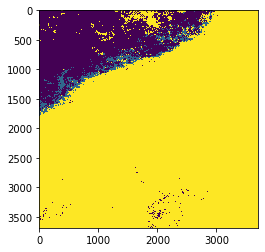

```python
# La imagen resultado no tiene sistema de coordenadas
plt.imshow(clasified)
```

## Agregar Sistema de Coordenadas a la Imágen Clasificada

Dado de la imágen que resulta de al clasificación es un arreglo **np.array** de dos dimensiones, no contiene los datos de localización de la imágen que permitirá su ubicación en el mapa. usarémos los datos de localización que se obtuvieron al principio del notebook cuando se carga el archivo .tif.

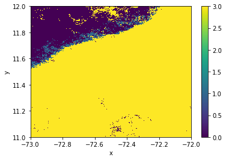

```python
# Define las coordenadas de los puntos
coords = {'x':data.x.values,'y':data.y.values}

# Define el orden de las dimensiones
dims = ('y','x')

# Define los metadatos o atributos
attrs = {
    'crs': data.crs,
    'transform': data.transform
}

data_array = xr.DataArray(data=clasified,coords=coords,dims=dims)
data_array.plot()
```